# Challenge 1

Ryan Wesslen (modified)

July 27, 2016

#### Descriptive analyses of text

Our goal is to learn how to find and analyze specific Tweets: Carolina Panther Tweets.

The dataset is a 20% sample of all Charlotte geo-located Tweets in a three month period (Dec 1 2015 to Feb 29 2016).

1. Read in the data. Run the `functions.R` file with pre-created functions.
- First, plot the dataset using the `timePlot` function. Add the parameter “smooth = TRUE” to add a smoothing parameter.
- What is causing the spikes?

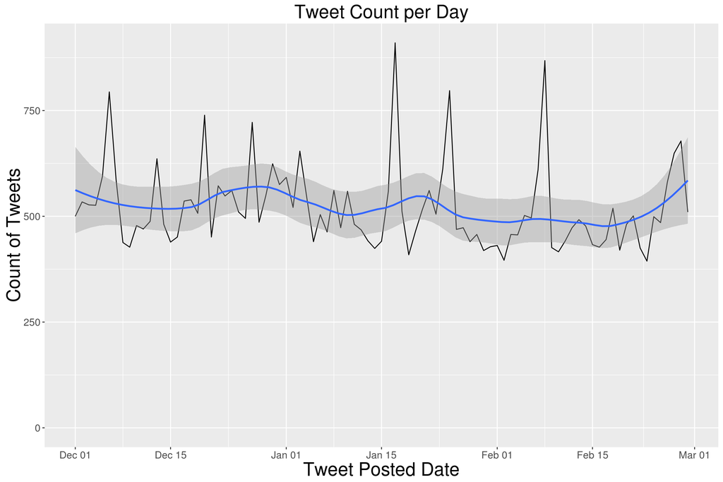

```r
# remember to set your working directory setwd()
raw.tweets <- read.csv("../datasets/CharlotteTweets20Sample.csv", stringsAsFactors = F)
source("../functions.R")
timePlot(raw.tweets, smooth = TRUE)
```

2. Save the most common hashtags (function `getCommonHashtags`); make sure to use the Tweet text (body) as the input. What are the top 10 hashtags?
- Repeat the same exercise with the handle function (`getCommonHandles`).
- Modify for the top 25 handles and hashtags.

```r
hashtags <- getCommonHashtags(raw.tweets$body)

head(hashtags, 25)
```

```
## hashtags
## #KeepPounding    #Charlotte           #NC   #realestate    #charlotte
##           487           458           443           429           256
## #keeppounding      #traffic       #trndnl        #photo      #listing
##           234           212           205           185           159
##          #clt       #Repost      #realtor         #CIAA         #SB50
##           154           144           133           123           109
##     #Panthers     #CIAA2016      #Concord          #CLT     #panthers
##            95            89            88            86            86
```

```r
handles <- getCommonHandles(raw.tweets$body)

head(handles, 25)
```

```
## handles
##      @cltairport        @Panthers        @midnight        @panthers
##              218              212              180              130
##      @EthanDolan            @ness         @hornets    @GraysonDolan
##              117               80               78               77
##    @SportsCenter       @F3theFort @realDonaldTrump     @nodabrewing
##               69               64               64               63
##    @CampersHaven   @marcuslemonis       @F3Isotope      @marielawtf
##               58               52               48               43
##          @oakley @LifeTimeFitness  @ChickenNGreens            @wcnc
##               39               38               36               36
```

3. Choose hashtags and handles that you think will best identify Carolina Panther Tweets.
- put the hashtags and handles into a character vector: names <- c(“keyword1”,“keyword2”)
- use `paste(names, collapse = "|")` to create a string of the keywords (with | as an OR). In a `grepl` function on the lower case of the Tweet’s text, create a new column of what rows meet your criteria.
- Use your new column vector as a row filter on the original datset. Run your new panthers dataset through `timePlot`.

Determine how many Panther Tweets you can identify for this period. Are these all Panther Tweets?

```r
panthers <- c("panther","keeppounding","panthernation","CameronNewton","LukeKuechly","cam newton ","thomas davis","greg olsen","kuechly","sb50","super bowl","sbvote","superbowl","keep pounding","camvp","josh norman")

# find only the Tweets that contain words in the first list
hit <- grepl(paste(panthers, collapse = "|"), tolower(raw.tweets$body))

# create a dataset with only the tweets that contain these words
panther.tweets <- raw.tweets[hit,]

nrow(panther.tweets)
```

```
## [1] 2048
```

```r
library(quanteda); library(RColorBrewer)

corpus <- corpus(panther.tweets$body)
docvars(corpus) <- data.frame(geo.type=raw.tweets$geo.type)

dfm <- dfm(corpus, ignoredFeatures = c(stopwords("english"), "t.co", "https", "rt", "amp", "http", "t.c", "can", "u"), ngrams=c(1,2))
```

```
## Creating a dfm from a corpus ...
##    ... lowercasing
##    ... tokenizing
##    ... indexing documents: 2,048 documents
##    ... indexing features: 20,517 feature types
##    ... removed 8,803 features, from 182 supplied (glob) feature types
##    ... created a 2048 x 11715 sparse dfm
##    ... complete.
## Elapsed time: 0.702 seconds.
```

```r
topfeatures(dfm)
```

```
## #keeppounding      panthers             @     @panthers          bank
##           732           572           479           341           218
##        @_bank       stadium         super       america     #panthers
##           209           194           192           191           184
```

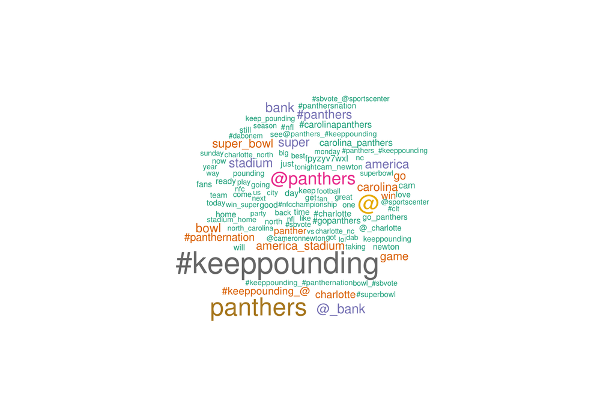

```r
plot(dfm, rot.per=0, scale=c(3.5, .75), colors=brewer.pal(8, "Dark2"), max.words=100)
```

5. Rerun the dfm but this time add in the geo.type as a group. Run a comparison word cloud (`comparison = TRUE`). This may take a few minutes.
- What are the differences in content between points and polygon Tweets? Replot the time series, this time creating one plot for each geo.type ()

```r
pnthrdfm <- dfm(corpus, groups = "geo.type", ignoredFeatures = c(stopwords("english"), "t.co", "https", "rt", "amp", "http", "t.c", "can", "u"), ngrams=c(1,2))
```

```
## Creating a dfm from a corpus ...
##    ... grouping texts by variable: geo.type
##    ... lowercasing
##    ... tokenizing
##    ... indexing documents: 2 documents
##    ... indexing features: 22,419 feature types
##    ... removed 9,343 features, from 182 supplied (glob) feature types
##    ... created a 2 x 13077 sparse dfm
##    ... complete.
## Elapsed time: 9.638 seconds.
```

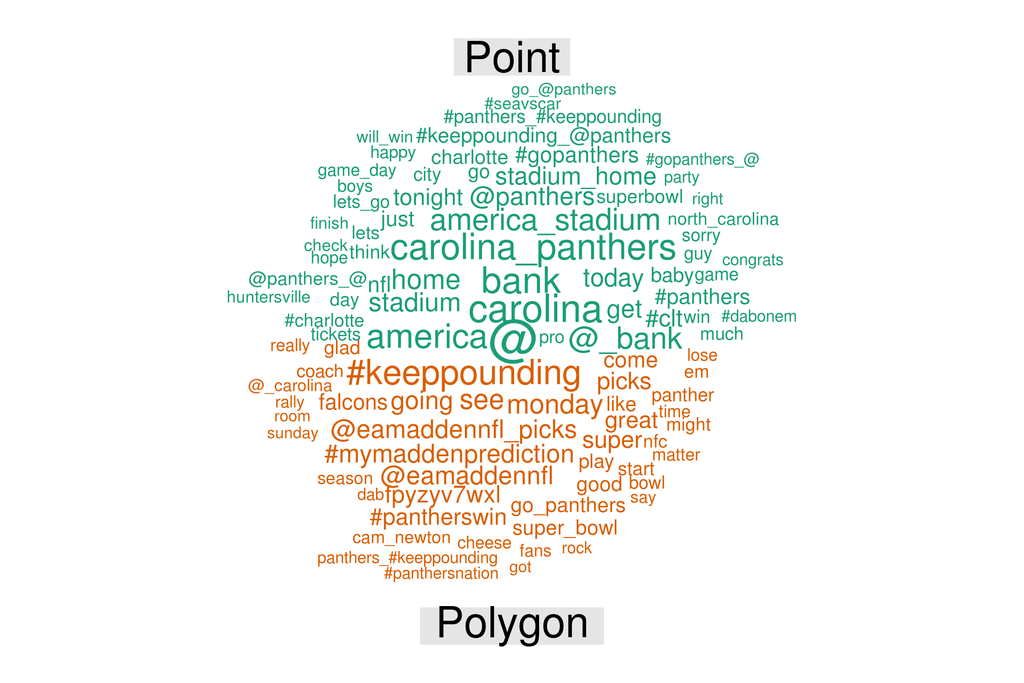

```r
plot(pnthrdfm, comparison = TRUE, rot.per=0, scale=c(3.5, .75), max.words=100)
```

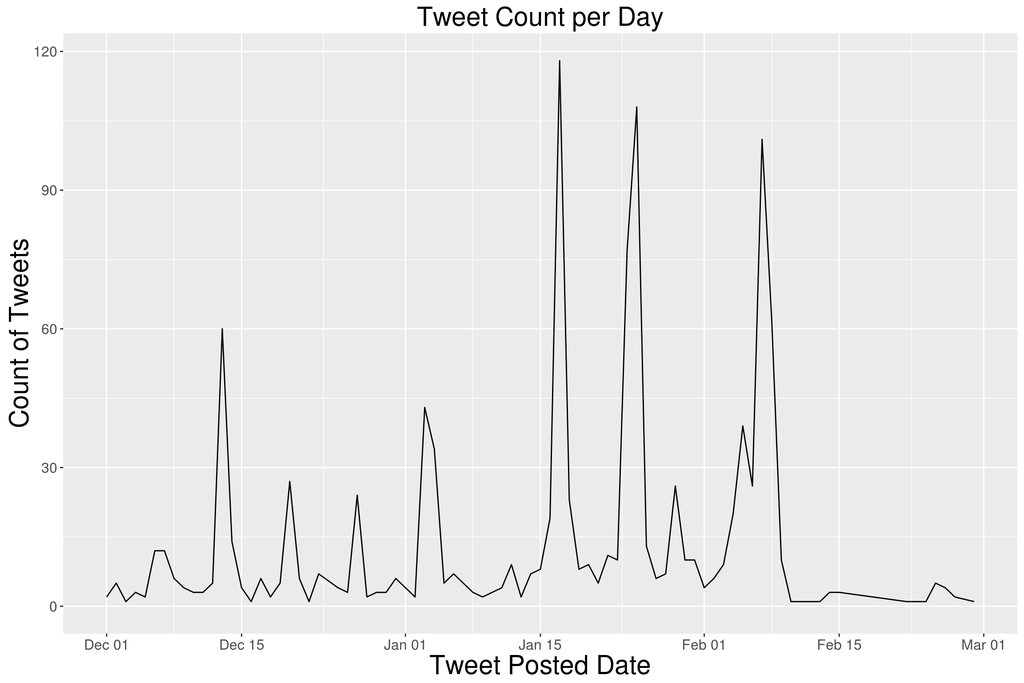

```r
par(nfrow = c(2,1))   # create a 2 x 1 matrix for plots
timePlot(panther.tweets[panther.tweets$geo.type == "Point",], smooth = FALSE)
```

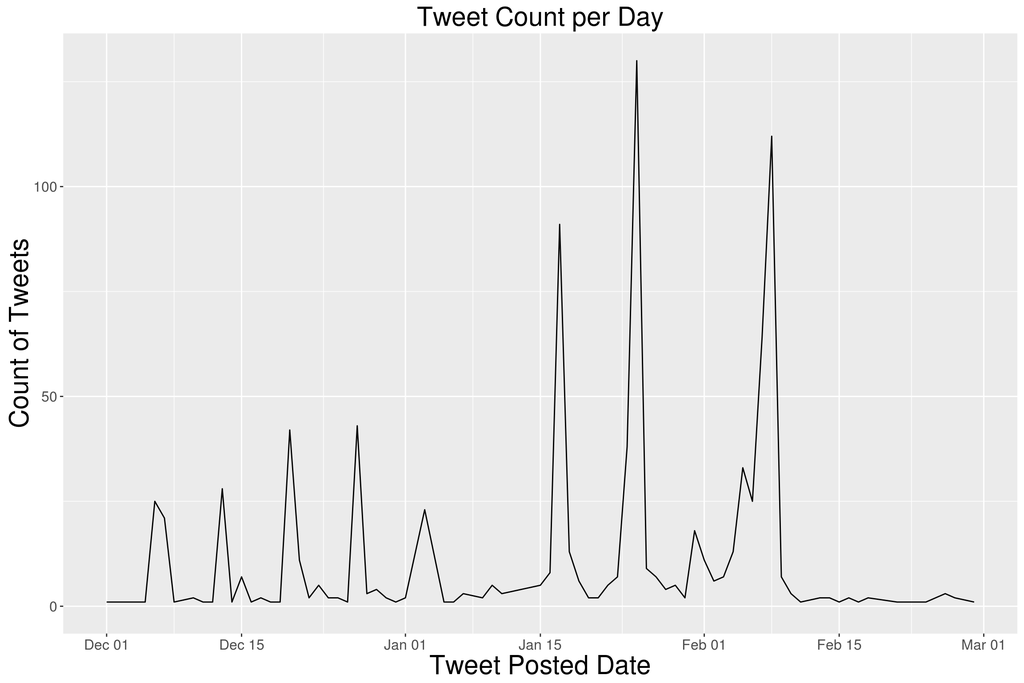

```r
timePlot(panther.tweets[panther.tweets$geo.type == "Polygon",], smooth = FALSE)
```

```r
par(nfrow = c(1,1))   # reset
```

BONUS. Additional pre-processing steps can sometimes improve results. Run additional pre-processing steps including: stemming, Twitter mode, bigrams or trigrams. Use ?dfm help to get a list of the parameters.

- Rerun your word clouds. What difference did these pre-processing steps make?
- Did you find new words to describe Carolina Panther Tweets?

```r
dfm <- dfm(corpus, ignoredFeatures = c(stopwords("english"), "t.co", "https", "rt", "amp", "http", "t.c", "can", "u"), stem = TRUE, twitter = TRUE, ngrams=c(1,3))
```

```
## Creating a dfm from a corpus ...
##    ... lowercasing
##    ... tokenizing
##    ... indexing documents: 2,048 documents
##    ... indexing features: 23,850 feature types
##    ... removed 13,691 features, from 182 supplied (glob) feature types
##    ... stemming features (English), trimmed 497 feature variants
##    ... created a 2048 x 9663 sparse dfm
##    ... complete.
## Elapsed time: 0.988 seconds.
```

```r
topfeatures(dfm)
```

```
## #keeppound    panther          @   @panther       bank    stadium
##        732        676        479        341        218        194
##      super    america         go       bowl
##        192        191        187        186
```

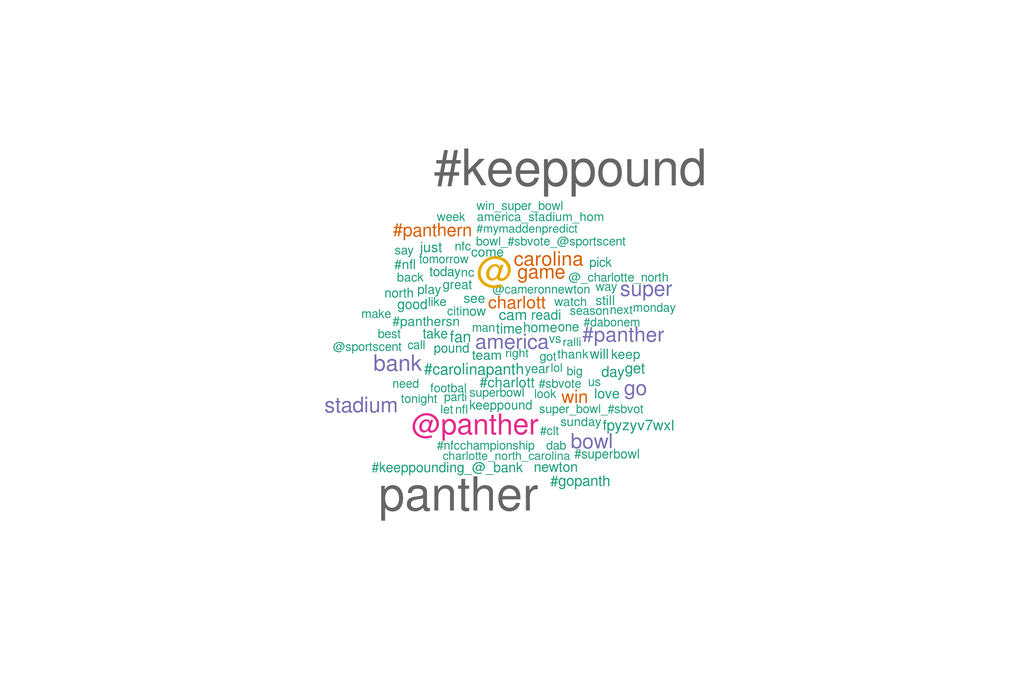

```r
plot(dfm, rot.per=0, scale=c(3.5, .75), colors=brewer.pal(8, "Dark2"), max.words=100)
```